# Business Analytics_Final Project_A

Dolores Chu, Charity Elijah, Cameron Croghan, Saleh

11/27/2019

First, load library and read in data. Checking to see how many observation/vairables are in the dataset.

```r
library(C50)
data(churn)
remove(churnTest)
nrow(churnTrain)
```

```
## [1] 3333
```

```r
colnames(churnTrain)
```

```
##  [1] "state"                         "account_length"
##  [3] "area_code"                     "international_plan"
##  [5] "voice_mail_plan"               "number_vmail_messages"
##  [7] "total_day_minutes"             "total_day_calls"
##  [9] "total_day_charge"              "total_eve_minutes"
## [11] "total_eve_calls"               "total_eve_charge"
## [13] "total_night_minutes"           "total_night_calls"
## [15] "total_night_charge"            "total_intl_minutes"
## [17] "total_intl_calls"              "total_intl_charge"
## [19] "number_customer_service_calls" "churn"
```

```r
str(churnTrain)
```

```
## 'data.frame':    3333 obs. of  20 variables:
##  $ state                        : Factor w/ 51 levels "AK","AL","AR",..: 17 36 32 36 37 2 20 25 19 50 ...
##  $ account_length               : int  128 107 137 84 75 118 121 147 117 141 ...
##  $ area_code                    : Factor w/ 3 levels "area_code_408",..: 2 2 2 1 2 3 3 2 1 2 ...
##  $ international_plan           : Factor w/ 2 levels "no","yes": 1 1 1 2 2 2 1 2 1 2 ...
##  $ voice_mail_plan              : Factor w/ 2 levels "no","yes": 2 2 1 1 1 1 2 1 1 2 ...
##  $ number_vmail_messages        : int  25 26 0 0 0 0 24 0 0 37 ...
##  $ total_day_minutes            : num  265 162 243 299 167 ...
##  $ total_day_calls              : int  110 123 114 71 113 98 88 79 97 84 ...
##  $ total_day_charge             : num  45.1 27.5 41.4 50.9 28.3 ...
##  $ total_eve_minutes            : num  197.4 195.5 121.2 61.9 148.3 ...
##  $ total_eve_calls              : int  99 103 110 88 122 101 108 94 80 111 ...
##  $ total_eve_charge             : num  16.78 16.62 10.3 5.26 12.61 ...
##  $ total_night_minutes          : num  245 254 163 197 187 ...
##  $ total_night_calls            : int  91 103 104 89 121 118 118 96 90 97 ...
##  $ total_night_charge           : num  11.01 11.45 7.32 8.86 8.41 ...
##  $ total_intl_minutes           : num  10 13.7 12.2 6.6 10.1 6.3 7.5 7.1 8.7 11.2 ...
##  $ total_intl_calls             : int  3 3 5 7 3 6 7 6 4 5 ...
##  $ total_intl_charge            : num  2.7 3.7 3.29 1.78 2.73 1.7 2.03 1.92 2.35 3.02 ...
##  $ number_customer_service_calls: int  1 1 0 2 3 0 3 0 1 0 ...
##  $ churn                        : Factor w/ 2 levels "yes","no": 2 2 2 2 2 2 2 2 2 2 ...
```

Checking for missing value– there is no missing value!

```r
summary(is.na(churnTrain))
```

```
##    state         account_length  area_code       international_plan
##  Mode :logical   Mode :logical   Mode :logical   Mode :logical
##  FALSE:3333      FALSE:3333      FALSE:3333      FALSE:3333
##  voice_mail_plan number_vmail_messages total_day_minutes total_day_calls
##  Mode :logical   Mode :logical         Mode :logical     Mode :logical
##  FALSE:3333      FALSE:3333            FALSE:3333        FALSE:3333
##  total_day_charge total_eve_minutes total_eve_calls total_eve_charge
##  Mode :logical    Mode :logical     Mode :logical   Mode :logical
##  FALSE:3333       FALSE:3333        FALSE:3333      FALSE:3333
##  total_night_minutes total_night_calls total_night_charge
##  Mode :logical       Mode :logical     Mode :logical
##  FALSE:3333          FALSE:3333        FALSE:3333
##  total_intl_minutes total_intl_calls total_intl_charge
##  Mode :logical      Mode :logical    Mode :logical
##  FALSE:3333         FALSE:3333       FALSE:3333
##  number_customer_service_calls   churn
##  Mode :logical                 Mode :logical
##  FALSE:3333                    FALSE:3333
```

```r
str(churnTrain)
```

```
## 'data.frame':    3333 obs. of  20 variables:
##  $ state                        : Factor w/ 51 levels "AK","AL","AR",..: 17 36 32 36 37 2 20 25 19 50 ...
##  $ account_length               : int  128 107 137 84 75 118 121 147 117 141 ...
##  $ area_code                    : Factor w/ 3 levels "area_code_408",..: 2 2 2 1 2 3 3 2 1 2 ...
##  $ international_plan           : Factor w/ 2 levels "no","yes": 1 1 1 2 2 2 1 2 1 2 ...
##  $ voice_mail_plan              : Factor w/ 2 levels "no","yes": 2 2 1 1 1 1 2 1 1 2 ...
##  $ number_vmail_messages        : int  25 26 0 0 0 0 24 0 0 37 ...
##  $ total_day_minutes            : num  265 162 243 299 167 ...
##  $ total_day_calls              : int  110 123 114 71 113 98 88 79 97 84 ...
##  $ total_day_charge             : num  45.1 27.5 41.4 50.9 28.3 ...
##  $ total_eve_minutes            : num  197.4 195.5 121.2 61.9 148.3 ...
##  $ total_eve_calls              : int  99 103 110 88 122 101 108 94 80 111 ...
##  $ total_eve_charge             : num  16.78 16.62 10.3 5.26 12.61 ...
##  $ total_night_minutes          : num  245 254 163 197 187 ...
##  $ total_night_calls            : int  91 103 104 89 121 118 118 96 90 97 ...
##  $ total_night_charge           : num  11.01 11.45 7.32 8.86 8.41 ...
##  $ total_intl_minutes           : num  10 13.7 12.2 6.6 10.1 6.3 7.5 7.1 8.7 11.2 ...
##  $ total_intl_calls             : int  3 3 5 7 3 6 7 6 4 5 ...
##  $ total_intl_charge            : num  2.7 3.7 3.29 1.78 2.73 1.7 2.03 1.92 2.35 3.02 ...
##  $ number_customer_service_calls: int  1 1 0 2 3 0 3 0 1 0 ...
##  $ churn                        : Factor w/ 2 levels "yes","no": 2 2 2 2 2 2 2 2 2 2 ...
```

```r
summary(churnTrain)
```

```
##      state      account_length          area_code    international_plan
##  WV     : 106   Min.   :  1.0   area_code_408: 838   no :3010
##  MN     :  84   1st Qu.: 74.0   area_code_415:1655   yes: 323
##  NY     :  83   Median :101.0   area_code_510: 840
##  AL     :  80   Mean   :101.1
##  OH     :  78   3rd Qu.:127.0
##  OR     :  78   Max.   :243.0
##  (Other):2824
##  voice_mail_plan number_vmail_messages total_day_minutes total_day_calls
##  no :2411        Min.   : 0.000        Min.   :  0.0     Min.   :  0.0
##  yes: 922        1st Qu.: 0.000        1st Qu.:143.7     1st Qu.: 87.0
##                  Median : 0.000        Median :179.4     Median :101.0
##                  Mean   : 8.099        Mean   :179.8     Mean   :100.4
##                  3rd Qu.:20.000        3rd Qu.:216.4     3rd Qu.:114.0
##                  Max.   :51.000        Max.   :350.8     Max.   :165.0
##
##  total_day_charge total_eve_minutes total_eve_calls total_eve_charge
##  Min.   : 0.00    Min.   :  0.0     Min.   :  0.0   Min.   : 0.00
##  1st Qu.:24.43    1st Qu.:166.6     1st Qu.: 87.0   1st Qu.:14.16
##  Median :30.50    Median :201.4     Median :100.0   Median :17.12
##  Mean   :30.56    Mean   :201.0     Mean   :100.1   Mean   :17.08
##  3rd Qu.:36.79    3rd Qu.:235.3     3rd Qu.:114.0   3rd Qu.:20.00
##  Max.   :59.64    Max.   :363.7     Max.   :170.0   Max.   :30.91
##
##  total_night_minutes total_night_calls total_night_charge
##  Min.   : 23.2       Min.   : 33.0     Min.   : 1.040
##  1st Qu.:167.0       1st Qu.: 87.0     1st Qu.: 7.520
##  Median :201.2       Median :100.0     Median : 9.050
##  Mean   :200.9       Mean   :100.1     Mean   : 9.039
##  3rd Qu.:235.3       3rd Qu.:113.0     3rd Qu.:10.590
##  Max.   :395.0       Max.   :175.0     Max.   :17.770
##
##  total_intl_minutes total_intl_calls total_intl_charge
##  Min.   : 0.00      Min.   : 0.000   Min.   :0.000
##  1st Qu.: 8.50      1st Qu.: 3.000   1st Qu.:2.300
##  Median :10.30      Median : 4.000   Median :2.780
##  Mean   :10.24      Mean   : 4.479   Mean   :2.765
##  3rd Qu.:12.10      3rd Qu.: 6.000   3rd Qu.:3.270
##  Max.   :20.00      Max.   :20.000   Max.   :5.400
##
##  number_customer_service_calls churn
##  Min.   :0.000                 yes: 483
##  1st Qu.:1.000                 no :2850
##  Median :1.000
##  Mean   :1.563
##  3rd Qu.:2.000
##  Max.   :9.000
##
```

In order to evaluate data performance and make adjustment, we split the traininng data into 2:a training set(80%) and a validation set(20%)

```r
library(caret)
set.seed(123)
Train_index <- createDataPartition(churnTrain$churn,p=0.8,list = FALSE)
Data_Train <- churnTrain[Train_index,]
Data_Validation <- churnTrain[-Train_index,]
```

Model_1 used all predictors except for state. Logistic regression models do not handle categorical vairables with a large amount of possible values very well. In addition, this variable does not have so much theoretical importance since we don’t care too much about differentiating between states.

```r
library(ISLR)
Model_1 = glm(churn~account_length+area_code+international_plan+voice_mail_plan+number_vmail_messages+total_day_minutes+total_day_calls+total_day_charge+total_eve_minutes+total_eve_calls+total_eve_charge+total_night_minutes+total_night_calls+total_night_charge+total_intl_minutes+total_intl_calls+total_intl_charge+number_customer_service_calls, family = "binomial", data = Data_Train)
summary(Model_1)
```

```
##
## Call:
## glm(formula = churn ~ account_length + area_code + international_plan +
##     voice_mail_plan + number_vmail_messages + total_day_minutes +
##     total_day_calls + total_day_charge + total_eve_minutes +
##     total_eve_calls + total_eve_charge + total_night_minutes +
##     total_night_calls + total_night_charge + total_intl_minutes +
##     total_intl_calls + total_intl_charge + number_customer_service_calls,
##     family = "binomial", data = Data_Train)
##
## Deviance Residuals:
##     Min       1Q   Median       3Q      Max
## -3.2286   0.2036   0.3453   0.5128   2.1693
##
## Coefficients:
##                                 Estimate Std. Error z value Pr(>|z|)
## (Intercept)                    8.128e+00  8.082e-01  10.057  < 2e-16 ***
## account_length                -7.014e-04  1.521e-03  -0.461  0.64471
## area_codearea_code_415         3.599e-02  1.528e-01   0.236  0.81378
## area_codearea_code_510         1.297e-01  1.772e-01   0.732  0.46419
## international_planyes         -2.070e+00  1.621e-01 -12.769  < 2e-16 ***
## voice_mail_planyes             1.928e+00  6.389e-01   3.018  0.00255 **
## number_vmail_messages         -3.318e-02  2.014e-02  -1.648  0.09942 .
## total_day_minutes             -4.224e-01  3.663e+00  -0.115  0.90818
## total_day_calls               -4.432e-03  3.103e-03  -1.428  0.15317
## total_day_charge               2.408e+00  2.154e+01   0.112  0.91101
## total_eve_minutes             -1.707e+00  1.826e+00  -0.935  0.34992
## total_eve_calls               -8.464e-05  3.143e-03  -0.027  0.97851
## total_eve_charge               2.000e+01  2.148e+01   0.931  0.35180
## total_night_minutes            1.300e-01  9.876e-01   0.132  0.89527
## total_night_calls              1.886e-03  3.183e-03   0.593  0.55350
## total_night_charge            -2.956e+00  2.195e+01  -0.135  0.89286
## total_intl_minutes             8.296e-01  5.918e+00   0.140  0.88851
## total_intl_calls               7.378e-02  2.722e-02   2.710  0.00672 **
## total_intl_charge             -3.391e+00  2.192e+01  -0.155  0.87705
## number_customer_service_calls -4.869e-01  4.430e-02 -10.992  < 2e-16 ***
## ---
## Signif. codes:  0 '***' 0.001 '**' 0.01 '*' 0.05 '.' 0.1 ' ' 1
##
## (Dispersion parameter for binomial family taken to be 1)
##
##     Null deviance: 2209.0  on 2666  degrees of freedom
## Residual deviance: 1740.7  on 2647  degrees of freedom
## AIC: 1780.7
##
## Number of Fisher Scoring iterations: 6
```

```r
Predicted_label_1<- predict(Model_1, newdata = Data_Validation, type = "response")
head(Predicted_label_1)
```

```
##         3        10        11        15        18        25
## 0.9280540 0.5154821 0.7724464 0.7435677 0.8443532 0.9783109
```

```r
Predicted_values_1 <- as.factor(Predicted_label_1 > 0.5)
head(Predicted_values_1)
```

```
##    3   10   11   15   18   25
## TRUE TRUE TRUE TRUE TRUE TRUE
## Levels: FALSE TRUE
```

```r
levels(Predicted_values_1) <- list(Yes = "FALSE", No = "TRUE")
Confusion_matrix_1 <-table(Predicted_1 = Predicted_values_1, Actual = Data_Validation$churn)
summary(Model_1)
```

```
##
## Call:
## glm(formula = churn ~ account_length + area_code + international_plan +
##     voice_mail_plan + number_vmail_messages + total_day_minutes +
##     total_day_calls + total_day_charge + total_eve_minutes +
##     total_eve_calls + total_eve_charge + total_night_minutes +
##     total_night_calls + total_night_charge + total_intl_minutes +
##     total_intl_calls + total_intl_charge + number_customer_service_calls,
##     family = "binomial", data = Data_Train)
##
## Deviance Residuals:
##     Min       1Q   Median       3Q      Max
## -3.2286   0.2036   0.3453   0.5128   2.1693
##
## Coefficients:
##                                 Estimate Std. Error z value Pr(>|z|)
## (Intercept)                    8.128e+00  8.082e-01  10.057  < 2e-16 ***
## account_length                -7.014e-04  1.521e-03  -0.461  0.64471
## area_codearea_code_415         3.599e-02  1.528e-01   0.236  0.81378
## area_codearea_code_510         1.297e-01  1.772e-01   0.732  0.46419
## international_planyes         -2.070e+00  1.621e-01 -12.769  < 2e-16 ***
## voice_mail_planyes             1.928e+00  6.389e-01   3.018  0.00255 **
## number_vmail_messages         -3.318e-02  2.014e-02  -1.648  0.09942 .
## total_day_minutes             -4.224e-01  3.663e+00  -0.115  0.90818
## total_day_calls               -4.432e-03  3.103e-03  -1.428  0.15317
## total_day_charge               2.408e+00  2.154e+01   0.112  0.91101
## total_eve_minutes             -1.707e+00  1.826e+00  -0.935  0.34992
## total_eve_calls               -8.464e-05  3.143e-03  -0.027  0.97851
## total_eve_charge               2.000e+01  2.148e+01   0.931  0.35180
## total_night_minutes            1.300e-01  9.876e-01   0.132  0.89527
## total_night_calls              1.886e-03  3.183e-03   0.593  0.55350
## total_night_charge            -2.956e+00  2.195e+01  -0.135  0.89286
## total_intl_minutes             8.296e-01  5.918e+00   0.140  0.88851
## total_intl_calls               7.378e-02  2.722e-02   2.710  0.00672 **
## total_intl_charge             -3.391e+00  2.192e+01  -0.155  0.87705
## number_customer_service_calls -4.869e-01  4.430e-02 -10.992  < 2e-16 ***
## ---
## Signif. codes:  0 '***' 0.001 '**' 0.01 '*' 0.05 '.' 0.1 ' ' 1
##
## (Dispersion parameter for binomial family taken to be 1)
##
##     Null deviance: 2209.0  on 2666  degrees of freedom
## Residual deviance: 1740.7  on 2647  degrees of freedom
## AIC: 1780.7
##
## Number of Fisher Scoring iterations: 6
```

```r
library(pROC)
roc(Data_Validation$churn, Predicted_label_1)
```

```
##
## Call:
## roc.default(response = Data_Validation$churn, predictor = Predicted_label_1)
##
## Data: Predicted_label_1 in 96 controls (Data_Validation$churn yes) < 570 cases (Data_Validation$churn no).
## Area under the curve: 0.847
```

Model_1.1 takes out area code as well.

```r
library(ISLR)
Model_1.1 = glm(churn~account_length+international_plan+voice_mail_plan+number_vmail_messages+total_day_minutes+total_day_calls+total_day_charge+total_eve_minutes+total_eve_calls+total_eve_charge+total_night_minutes+total_night_calls+total_night_charge+total_intl_minutes+total_intl_calls+total_intl_charge+number_customer_service_calls, family = "binomial", data = Data_Train)
summary(Model_1.1)
```

```
##
## Call:
## glm(formula = churn ~ account_length + international_plan + voice_mail_plan +
##     number_vmail_messages + total_day_minutes + total_day_calls +
##     total_day_charge + total_eve_minutes + total_eve_calls +
##     total_eve_charge + total_night_minutes + total_night_calls +
##     total_night_charge + total_intl_minutes + total_intl_calls +
##     total_intl_charge + number_customer_service_calls, family = "binomial",
##     data = Data_Train)
##
## Deviance Residuals:
##     Min       1Q   Median       3Q      Max
## -3.2311   0.2044   0.3453   0.5153   2.1469
##
## Coefficients:
##                                 Estimate Std. Error z value Pr(>|z|)
## (Intercept)                    8.179e+00  8.020e-01  10.198  < 2e-16 ***
## account_length                -7.507e-04  1.519e-03  -0.494  0.62119
## international_planyes         -2.064e+00  1.619e-01 -12.753  < 2e-16 ***
## voice_mail_planyes             1.922e+00  6.386e-01   3.009  0.00262 **
## number_vmail_messages         -3.300e-02  2.014e-02  -1.639  0.10122
## total_day_minutes             -4.459e-01  3.661e+00  -0.122  0.90306
## total_day_calls               -4.443e-03  3.103e-03  -1.432  0.15217
## total_day_charge               2.546e+00  2.153e+01   0.118  0.90590
## total_eve_minutes             -1.801e+00  1.821e+00  -0.989  0.32275
## total_eve_calls               -4.732e-05  3.141e-03  -0.015  0.98798
## total_eve_charge               2.111e+01  2.142e+01   0.985  0.32453
## total_night_minutes            1.482e-01  9.868e-01   0.150  0.88059
## total_night_calls              1.903e-03  3.181e-03   0.598  0.54960
## total_night_charge            -3.361e+00  2.193e+01  -0.153  0.87819
## total_intl_minutes             1.049e+00  5.910e+00   0.177  0.85915
## total_intl_calls               7.403e-02  2.721e-02   2.721  0.00651 **
## total_intl_charge             -4.202e+00  2.189e+01  -0.192  0.84773
## number_customer_service_calls -4.856e-01  4.424e-02 -10.976  < 2e-16 ***
## ---
## Signif. codes:  0 '***' 0.001 '**' 0.01 '*' 0.05 '.' 0.1 ' ' 1
##
## (Dispersion parameter for binomial family taken to be 1)
##
##     Null deviance: 2209.0  on 2666  degrees of freedom
## Residual deviance: 1741.3  on 2649  degrees of freedom
## AIC: 1777.3
##
## Number of Fisher Scoring iterations: 6
```

```r
Predicted_label_1.1<- predict(Model_1.1, newdata = Data_Validation, type = "response")
head(Predicted_label_1.1)
```

```
##         3        10        11        15        18        25
## 0.9285675 0.5198978 0.7752464 0.7466325 0.8342754 0.9764717
```

```r
Predicted_values_1.1 <- as.factor(Predicted_label_1.1 > 0.5)
head(Predicted_values_1.1)
```

```
##    3   10   11   15   18   25
## TRUE TRUE TRUE TRUE TRUE TRUE
## Levels: FALSE TRUE
```

```r
levels(Predicted_values_1.1) <- list(Yes = "FALSE", No = "TRUE")
Confusion_matrix_1.1 <-table(Predicted_1.1 = Predicted_values_1.1, Actual = Data_Validation$churn)
summary(Model_1.1)
```

```
##
## Call:
## glm(formula = churn ~ account_length + international_plan + voice_mail_plan +
##     number_vmail_messages + total_day_minutes + total_day_calls +
##     total_day_charge + total_eve_minutes + total_eve_calls +
##     total_eve_charge + total_night_minutes + total_night_calls +
##     total_night_charge + total_intl_minutes + total_intl_calls +
##     total_intl_charge + number_customer_service_calls, family = "binomial",
##     data = Data_Train)
##
## Deviance Residuals:
##     Min       1Q   Median       3Q      Max
## -3.2311   0.2044   0.3453   0.5153   2.1469
##
## Coefficients:
##                                 Estimate Std. Error z value Pr(>|z|)
## (Intercept)                    8.179e+00  8.020e-01  10.198  < 2e-16 ***
## account_length                -7.507e-04  1.519e-03  -0.494  0.62119
## international_planyes         -2.064e+00  1.619e-01 -12.753  < 2e-16 ***
## voice_mail_planyes             1.922e+00  6.386e-01   3.009  0.00262 **
## number_vmail_messages         -3.300e-02  2.014e-02  -1.639  0.10122
## total_day_minutes             -4.459e-01  3.661e+00  -0.122  0.90306
## total_day_calls               -4.443e-03  3.103e-03  -1.432  0.15217
## total_day_charge               2.546e+00  2.153e+01   0.118  0.90590
## total_eve_minutes             -1.801e+00  1.821e+00  -0.989  0.32275
## total_eve_calls               -4.732e-05  3.141e-03  -0.015  0.98798
## total_eve_charge               2.111e+01  2.142e+01   0.985  0.32453
## total_night_minutes            1.482e-01  9.868e-01   0.150  0.88059
## total_night_calls              1.903e-03  3.181e-03   0.598  0.54960
## total_night_charge            -3.361e+00  2.193e+01  -0.153  0.87819
## total_intl_minutes             1.049e+00  5.910e+00   0.177  0.85915
## total_intl_calls               7.403e-02  2.721e-02   2.721  0.00651 **
## total_intl_charge             -4.202e+00  2.189e+01  -0.192  0.84773
## number_customer_service_calls -4.856e-01  4.424e-02 -10.976  < 2e-16 ***
## ---
## Signif. codes:  0 '***' 0.001 '**' 0.01 '*' 0.05 '.' 0.1 ' ' 1
##
## (Dispersion parameter for binomial family taken to be 1)
##
##     Null deviance: 2209.0  on 2666  degrees of freedom
## Residual deviance: 1741.3  on 2649  degrees of freedom
## AIC: 1777.3
##
## Number of Fisher Scoring iterations: 6
```

```r
roc(Data_Validation$churn, Predicted_label_1.1)
```

```
##
## Call:
## roc.default(response = Data_Validation$churn, predictor = Predicted_label_1.1)
##
## Data: Predicted_label_1.1 in 96 controls (Data_Validation$churn yes) < 570 cases (Data_Validation$churn no).
## Area under the curve: 0.8485
```

Model_1.2 takes out co-variants.

```r
library(ISLR)
Model_1.2 = glm(churn~account_length+international_plan+voice_mail_plan+number_vmail_messages+total_day_minutes+total_day_calls+total_eve_minutes+total_eve_calls+total_night_minutes+total_night_calls+total_intl_minutes+total_intl_calls+number_customer_service_calls, family = "binomial", data = Data_Train)
summary(Model_1.2)
```

```
##
## Call:
## glm(formula = churn ~ account_length + international_plan + voice_mail_plan +
##     number_vmail_messages + total_day_minutes + total_day_calls +
##     total_eve_minutes + total_eve_calls + total_night_minutes +
##     total_night_calls + total_intl_minutes + total_intl_calls +
##     number_customer_service_calls, family = "binomial", data = Data_Train)
##
## Deviance Residuals:
##     Min       1Q   Median       3Q      Max
## -3.2177   0.2036   0.3439   0.5166   2.1052
##
## Coefficients:
##                                 Estimate Std. Error z value Pr(>|z|)
## (Intercept)                    8.168e+00  8.011e-01  10.196  < 2e-16 ***
## account_length                -7.272e-04  1.520e-03  -0.478 0.632398
## international_planyes         -2.061e+00  1.618e-01 -12.740  < 2e-16 ***
## voice_mail_planyes             1.902e+00  6.370e-01   2.987 0.002821 **
## number_vmail_messages         -3.237e-02  2.010e-02  -1.611 0.107257
## total_day_minutes             -1.314e-02  1.209e-03 -10.868  < 2e-16 ***
## total_day_calls               -4.352e-03  3.095e-03  -1.406 0.159745
## total_eve_minutes             -6.626e-03  1.268e-03  -5.225 1.74e-07 ***
## total_eve_calls               -6.843e-05  3.137e-03  -0.022 0.982597
## total_night_minutes           -3.030e-03  1.227e-03  -2.469 0.013548 *
## total_night_calls              1.941e-03  3.179e-03   0.611 0.541518
## total_intl_minutes            -8.559e-02  2.312e-02  -3.702 0.000214 ***
## total_intl_calls               7.394e-02  2.715e-02   2.724 0.006459 **
## number_customer_service_calls -4.856e-01  4.420e-02 -10.987  < 2e-16 ***
## ---
## Signif. codes:  0 '***' 0.001 '**' 0.01 '*' 0.05 '.' 0.1 ' ' 1
##
## (Dispersion parameter for binomial family taken to be 1)
##
##     Null deviance: 2209.0  on 2666  degrees of freedom
## Residual deviance: 1742.4  on 2653  degrees of freedom
## AIC: 1770.4
##
## Number of Fisher Scoring iterations: 6
```

```r
Predicted_label_1.2<- predict(Model_1.2, newdata = Data_Validation, type = "response")
head(Predicted_label_1.2)
```

```
##         3        10        11        15        18        25
## 0.9308110 0.5196377 0.7868499 0.7593636 0.8263224 0.9775633
```

```r
Predicted_values_1.2 <- as.factor(Predicted_label_1.2 > 0.5)
head(Predicted_values_1.2)
```

```
##    3   10   11   15   18   25
## TRUE TRUE TRUE TRUE TRUE TRUE
## Levels: FALSE TRUE
```

```r
levels(Predicted_values_1.2) <- list(Yes = "FALSE", No = "TRUE")
Confusion_matrix_1.2 <-table(Predicted_1.2 = Predicted_values_1.2, Actual = Data_Validation$churn)
summary(Model_1.2)
```

```
##
## Call:
## glm(formula = churn ~ account_length + international_plan + voice_mail_plan +
##     number_vmail_messages + total_day_minutes + total_day_calls +
##     total_eve_minutes + total_eve_calls + total_night_minutes +
##     total_night_calls + total_intl_minutes + total_intl_calls +
##     number_customer_service_calls, family = "binomial", data = Data_Train)
##
## Deviance Residuals:
##     Min       1Q   Median       3Q      Max
## -3.2177   0.2036   0.3439   0.5166   2.1052
##
## Coefficients:
##                                 Estimate Std. Error z value Pr(>|z|)
## (Intercept)                    8.168e+00  8.011e-01  10.196  < 2e-16 ***
## account_length                -7.272e-04  1.520e-03  -0.478 0.632398
## international_planyes         -2.061e+00  1.618e-01 -12.740  < 2e-16 ***
## voice_mail_planyes             1.902e+00  6.370e-01   2.987 0.002821 **
## number_vmail_messages         -3.237e-02  2.010e-02  -1.611 0.107257
## total_day_minutes             -1.314e-02  1.209e-03 -10.868  < 2e-16 ***
## total_day_calls               -4.352e-03  3.095e-03  -1.406 0.159745
## total_eve_minutes             -6.626e-03  1.268e-03  -5.225 1.74e-07 ***
## total_eve_calls               -6.843e-05  3.137e-03  -0.022 0.982597
## total_night_minutes           -3.030e-03  1.227e-03  -2.469 0.013548 *
## total_night_calls              1.941e-03  3.179e-03   0.611 0.541518
## total_intl_minutes            -8.559e-02  2.312e-02  -3.702 0.000214 ***
## total_intl_calls               7.394e-02  2.715e-02   2.724 0.006459 **
## number_customer_service_calls -4.856e-01  4.420e-02 -10.987  < 2e-16 ***
## ---
## Signif. codes:  0 '***' 0.001 '**' 0.01 '*' 0.05 '.' 0.1 ' ' 1
##
## (Dispersion parameter for binomial family taken to be 1)
##
##     Null deviance: 2209.0  on 2666  degrees of freedom
## Residual deviance: 1742.4  on 2653  degrees of freedom
## AIC: 1770.4
##
## Number of Fisher Scoring iterations: 6
```

```r
library(pROC)
roc(Data_Validation$churn, Predicted_label_1.2)
```

```
##
## Call:
## roc.default(response = Data_Validation$churn, predictor = Predicted_label_1.2)
##
## Data: Predicted_label_1.2 in 96 controls (Data_Validation$churn yes) < 570 cases (Data_Validation$churn no).
## Area under the curve: 0.85
```

```r
Model_2 = glm(churn~international_plan+voice_mail_plan+total_day_minutes+total_eve_minutes+total_night_minutes+total_intl_minutes+total_intl_calls+number_customer_service_calls, family = "binomial", data = Data_Train)
summary(Model_2)
```

```
##
## Call:
## glm(formula = churn ~ international_plan + voice_mail_plan +
##     total_day_minutes + total_eve_minutes + total_night_minutes +
##     total_intl_minutes + total_intl_calls + number_customer_service_calls,
##     family = "binomial", data = Data_Train)
##
## Deviance Residuals:
##     Min       1Q   Median       3Q      Max
## -3.0635   0.2088   0.3430   0.5193   2.0819
##
## Coefficients:
##                                Estimate Std. Error z value Pr(>|z|)
## (Intercept)                    7.833104   0.572242  13.688  < 2e-16 ***
## international_planyes         -2.058167   0.161276 -12.762  < 2e-16 ***
## voice_mail_planyes             0.931356   0.161123   5.780 7.45e-09 ***
## total_day_minutes             -0.013172   0.001208 -10.900  < 2e-16 ***
## total_eve_minutes             -0.006550   0.001265  -5.179 2.24e-07 ***
## total_night_minutes           -0.003009   0.001224  -2.458 0.013971 *
## total_intl_minutes            -0.086143   0.023066  -3.735 0.000188 ***
## total_intl_calls               0.074212   0.027053   2.743 0.006085 **
## number_customer_service_calls -0.486769   0.044109 -11.036  < 2e-16 ***
## ---
## Signif. codes:  0 '***' 0.001 '**' 0.01 '*' 0.05 '.' 0.1 ' ' 1
##
## (Dispersion parameter for binomial family taken to be 1)
##
##     Null deviance: 2209.0  on 2666  degrees of freedom
## Residual deviance: 1747.8  on 2658  degrees of freedom
## AIC: 1765.8
##
## Number of Fisher Scoring iterations: 5
```

```r
Predicted_label_2 <- predict(Model_2, newdata = Data_Validation, type = "response")
head(Predicted_label_2)
```

```
##         3        10        11        15        18        25
## 0.9348668 0.5670905 0.8040534 0.7290876 0.8272951 0.9760334
```

```r
Predicted_values_2 <- as.factor(Predicted_label_2 > 0.5)
head(Predicted_values_2)
```

```
##    3   10   11   15   18   25
## TRUE TRUE TRUE TRUE TRUE TRUE
## Levels: FALSE TRUE
```

```r
levels(Predicted_values_2) <- list(Yes = "FALSE", No = "TRUE")
Confusion_matrix_2 <- table(Predicted_2 = Predicted_values_2, Actual = Data_Validation$churn)
roc(Data_Validation$churn, Predicted_label_1)
```

```
##
## Call:
## roc.default(response = Data_Validation$churn, predictor = Predicted_label_1)
##
## Data: Predicted_label_1 in 96 controls (Data_Validation$churn yes) < 570 cases (Data_Validation$churn no).
## Area under the curve: 0.847
```

Model_1.2 will be our final model. Let’s first review the performance with AUC.

```r
library(pROC)
roc(Data_Validation$churn, Predicted_label_1.2)
```

```
##
## Call:
## roc.default(response = Data_Validation$churn, predictor = Predicted_label_1.2)
##
## Data: Predicted_label_1.2 in 96 controls (Data_Validation$churn yes) < 570 cases (Data_Validation$churn no).
## Area under the curve: 0.85
```

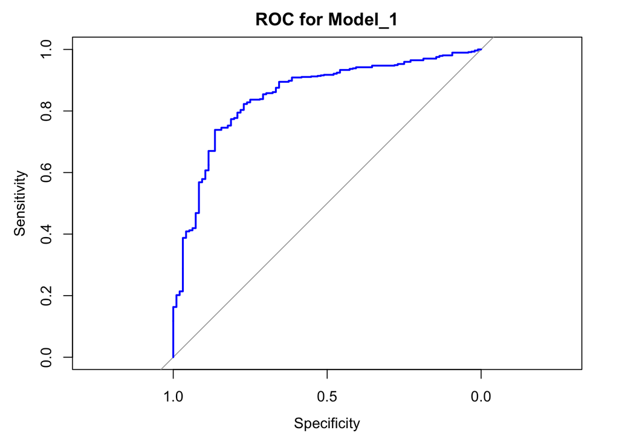

```r
plot(roc(Data_Validation$churn, Predicted_label_1.2), col='blue', main = "ROC for Model_1")
```

Next, let’s considering the decision threshold. In our first model, using a threshold of 0.5, we have a true positive rate of 15%. The false positive rate is only 3%.

```r
Confusion_matrix_1.2
```

```
##              Actual
## Predicted_1.2 yes  no
##           Yes  14  17
##           No   82 553
```

Let’s see if we can improve this by raising the threshold to p>0.7. Now we have a 46% true positive rate! And the false positive rate is still relatively low (7%).

```r
Predicted_values_1.2 <- as.factor(Predicted_label_1.2 > 0.7)
head(Predicted_values_1.2)
```

```
##     3    10    11    15    18    25
##  TRUE FALSE  TRUE  TRUE  TRUE  TRUE
## Levels: FALSE TRUE
```

```r
levels(Predicted_values_1.2) <- list(Yes = "FALSE", No = "TRUE")
Confusion_matrix_1.2 <-table(Predicted_1.2 = Predicted_values_1.2, Actual = Data_Validation$churn)
Confusion_matrix_1.2
```

```
##              Actual
## Predicted_1.2 yes  no
##           Yes  44  41
##           No   52 529
```

Let’s see if we can improve even more by setting the threshold to p>0.8. Setting the threshold to p>0.8. gives us a 68% true positive rate, with a 14% false positive rate.

```r
Predicted_values_1.2 <- as.factor(Predicted_label_1.2 > 0.8)
head(Predicted_values_1.2)
```

```
##     3    10    11    15    18    25
##  TRUE FALSE FALSE FALSE  TRUE  TRUE
## Levels: FALSE TRUE
```

```r
levels(Predicted_values_1.2) <- list(Yes = "FALSE", No = "TRUE")
Confusion_matrix_1.2 <-table(Predicted_1.2 = Predicted_values_1.2, Actual = Data_Validation$churn)
Confusion_matrix_1.2
```

```
##              Actual
## Predicted_1.2 yes  no
##           Yes  65  81
##           No   31 489
```

What if we do p>0.9? The Tre positive rate increases to 89%, and the false positive rate increase to 36%.

```r
Predicted_values_1.2 <- as.factor(Predicted_label_1.2 > 0.9)
head(Predicted_values_1.2)
```

```
##     3    10    11    15    18    25
##  TRUE FALSE FALSE FALSE FALSE  TRUE
## Levels: FALSE TRUE
```

```r
levels(Predicted_values_1.2) <- list(Yes = "FALSE", No = "TRUE")
Confusion_matrix_1.2 <-table(Predicted_1.2 = Predicted_values_1.2, Actual = Data_Validation$churn)
Confusion_matrix_1.2
```

```
##              Actual
## Predicted_1.2 yes  no
##           Yes  85 204
##           No   11 366
```